# 3.3 Hierarchical models with latent variables

Jan Smyčka

18/01/2024

Here we will go through a simple hierarchical model with measurement error.

# Data

Imagine you were asked to measure sizes of the trees in tree avenue going to the lake. We would like to know whether the sizes of the trees increase with humidity. However, trees are difficult to measure. For this reason you have decided to measure every tree multiple times, using the triangulation - it is not precise, but it should give a reasonable idea on how high the trees are.

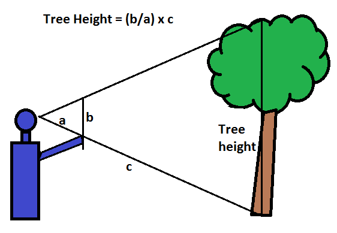

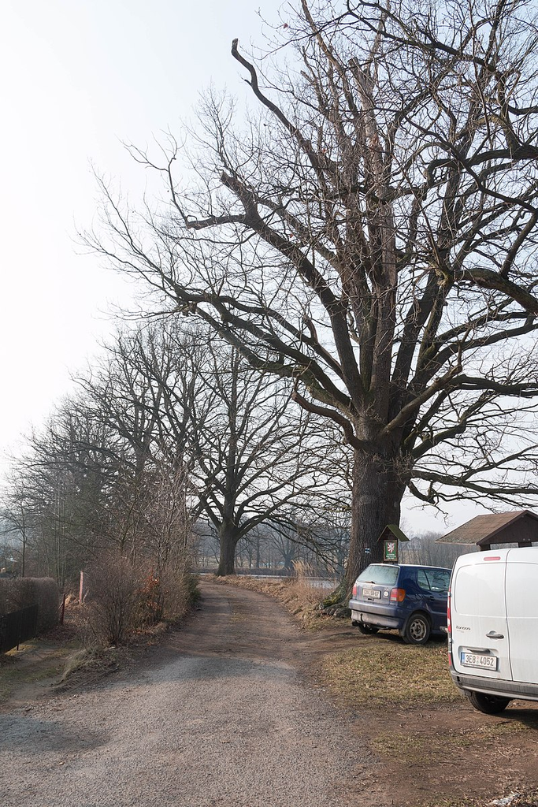

We can load the data and the rethinking package.

We can see it is two datasets, one containing all measurements for all trees, another one smaller (we’ll talk about it later).

```r
scdata
```

```
## $observed
##  [1]  98.51367 101.80741  99.63854 100.29765 102.08154 102.65499  99.35954
##  [8]  99.17081 101.78516 100.69613 104.29297 107.38552 104.95295 100.83970
## [15] 100.57027 101.52617 108.30205 106.73836 103.77992 104.01809 101.90837
## [22] 105.71269 105.90757 105.84192 103.30059 105.67553 103.50968 103.59292
## [29] 105.73007 106.46095 105.03624 104.80662 105.51613 105.11852 107.12571
## [36] 105.95968
##
## $humidity
## [1] 0.0 0.2 0.4 0.6 0.8 1.0
##
## $humidityex
##  [1] 0.0 0.2 0.2 0.2 0.2 0.4 0.4 0.4 0.4 0.4 0.6 0.6 0.6 0.8 0.8 0.8 0.8 0.8 0.8
## [20] 1.0 1.0 1.0 1.0 1.0 1.0 1.0 1.0 1.0 1.0 1.0 1.0 1.0 1.0 1.0 1.0 1.0
##
## $id
##  [1] 1 2 2 2 2 3 3 3 3 3 4 4 4 5 5 5 5 5 5 6 6 6 6 6 6 6 6 6 6 6 6 6 6 6 6 6
```

```r
sc1data
```

```
## $observed1
## [1]  98.51367 101.80741 102.65499 104.29297 100.83970 104.01809
##
## $humidity
## [1] 0.0 0.2 0.4 0.6 0.8 1.0
##
## $id
## [1] 1 2 3 4 5 6
```

Let’s plot the data in the first dataset, height observations against humidity. we see that there is another problem - it is easy to triangulate from the lake, so the trees in more humid environment were triangulated more times.

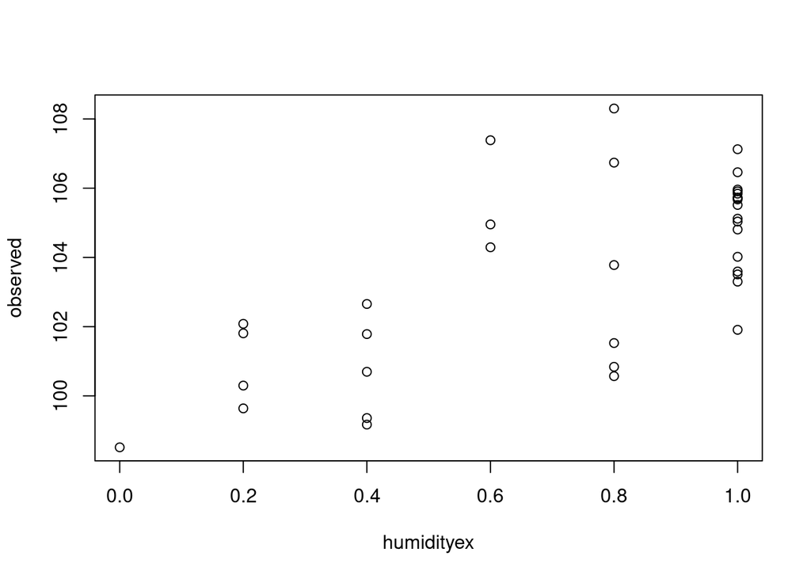

```r
plot(observed~humidityex,data=scdata)
```

If we ignored everything and fitted a frequentist linear model, this would be significant. Can you say why this approach is wrong?

```r
summary(lm(observed~humidityex,data=scdata))
```

```
##
## Call:
## lm(formula = observed ~ humidityex, data = scdata)
##
## Residuals:
##     Min      1Q  Median      3Q     Max
## -3.4049 -1.1876  0.0388  0.9974  4.5346
##
## Coefficients:
##             Estimate Std. Error t value Pr(>|t|)
## (Intercept)  99.4783     0.8283  120.10  < 2e-16 ***
## humidityex    5.6211     1.0390    5.41 5.04e-06 ***
## ---
## Signif. codes:  0 '***' 0.001 '**' 0.01 '*' 0.05 '.' 0.1 ' ' 1
##
## Residual standard error: 1.949 on 34 degrees of freedom
## Multiple R-squared:  0.4626, Adjusted R-squared:  0.4468
## F-statistic: 29.27 on 1 and 34 DF,  p-value: 5.035e-06
```

# Model

For modeling this system we can use latent variables. These are variables that are important for our thinking about the processes that generated the data, but they are not directly observable. Such as real height of the trees - we only have its estimates using triangulation, but not the exact values. Importantly, each tree can be triangulated with different precision dependent e.g. on shape of its crown.

```r
scmodel=alist(
  observed ~ dnorm(realsize[id], sigmam[id]),
  realsize[id] ~ dnorm(mu, sigma),
  mu <- alpha + beta*humidity,
  sigmam[id] ~ dexp(0.001),
  sigma ~ dexp(0.001),
  alpha ~ dnorm(0, 100),
  beta ~ dnorm(0,100)
)
```

We can fit the model.

```r
scposterior=ulam(scmodel,
                 data=scdata,iter = 10000)
```

[output not shown]

[output cut: 50 more lines]

[output not shown]

Explore the estimates.

```r
precis(scposterior)
```

```
## 12 vector or matrix parameters hidden. Use depth=2 to show them.
```

```
##            mean       sd       5.5%      94.5%     rhat  ess_bulk
## sigma  2.743997 3.873781  0.5021916   7.778699 1.002407  269.6556
## alpha 99.617453 4.081451 94.8390120 104.932330 1.001497 1370.9570
## beta   5.612220 6.194208 -1.7924246  12.883587 1.000618 1720.8311
```

There are multiple levels of parameters.

```r
precis(scposterior, depth=2)
```

```
##                   mean          sd        5.5%      94.5%     rhat  ess_bulk
## realsize[1]  99.750671   6.4169379  93.7537840 105.966275 1.000212 1524.4231
## realsize[2] 100.826944   1.0774912  99.1505505 102.374110 1.000223 1271.0747
## realsize[3] 101.039921   0.9672244  99.6038965 102.523055 1.002035 1345.1383
## realsize[4] 104.015750   1.8811418 101.4159450 106.803110 1.001408 1293.4435
## realsize[5] 103.799047   1.3006686 101.7558350 105.898165 1.002622 2436.8817
## realsize[6] 105.026781   0.3463593 104.4838350 105.575165 1.000807 2417.4489
## sigmam[1]   165.681219 338.3074587   1.0785421 760.733930 1.001280 1406.5393
## sigmam[2]     2.415173   2.4725622   0.8362943   5.840023 1.003650  561.5848
## sigmam[3]     2.283973   1.2659001   1.0792573   4.344999 1.000262 1177.8719
## sigmam[4]     5.757694  14.2391664   1.2511376  14.138406 1.000146 1467.7394
## sigmam[5]     4.248027   1.8881787   2.3269694   7.506685 1.003602 1644.1207
## sigmam[6]     1.439850   0.2780961   1.0708129   1.926901 1.000092 3041.4200
## sigma         2.743997   3.8737812   0.5021916   7.778699 1.002407  269.6556
## alpha        99.617453   4.0814512  94.8390120 104.932330 1.001497 1370.9570
## beta          5.612220   6.1942081  -1.7924246  12.883587 1.000618 1720.8311
```

Explore the convergence.

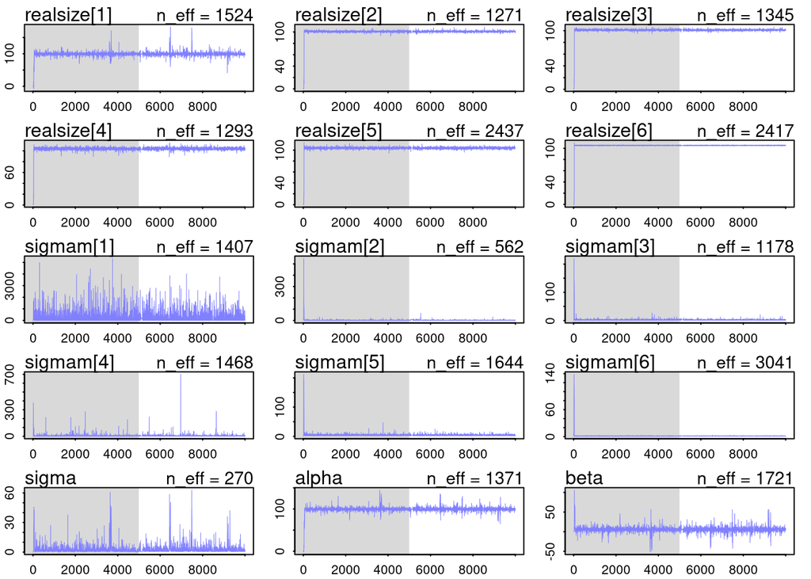

```r
traceplot(scposterior)
```

And plot the mean estimate and credibility lines.

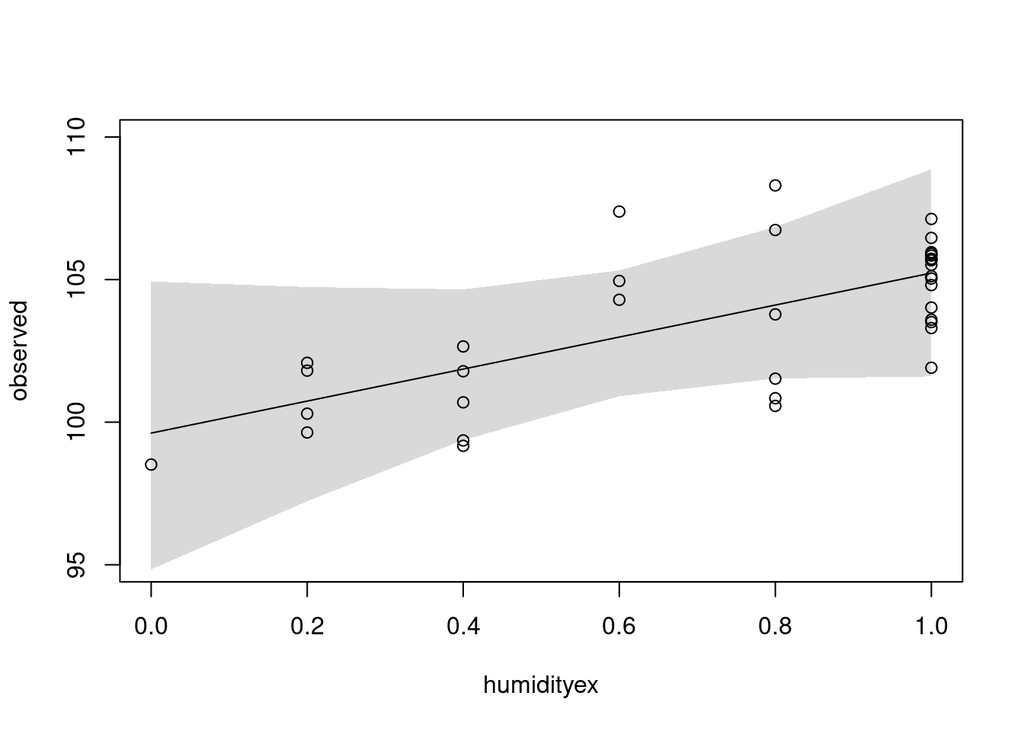

```r
yexpsc=link(scposterior)

yexpmeansc=apply(yexpsc,2, mean)
yexpPIsc=apply(yexpsc,2, PI)

plot(observed~humidityex, data=scdata, ylim=c(95,110))
lines(scdata$humidity , yexpmeansc)
shade(yexpPIsc , scdata$humidity)
```

# Complication and example 1

You are a particularly lazy researcher. Instead of triangulating every tree multiple times, you only did it once. How does it change the parameter inference? You can go explore it yourself.

```r
sc1data
```

```
## $observed1
## [1]  98.51367 101.80741 102.65499 104.29297 100.83970 104.01809
##
## $humidity
## [1] 0.0 0.2 0.4 0.6 0.8 1.0
##
## $id
## [1] 1 2 3 4 5 6
```

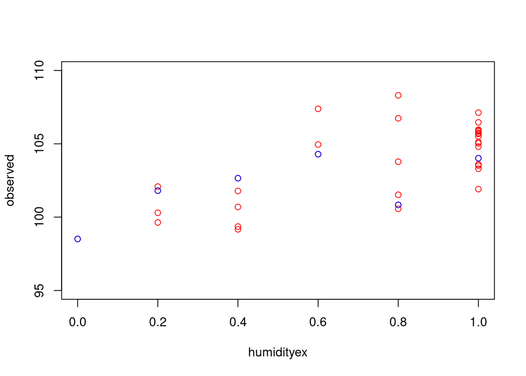

```r
plot(observed~humidityex, data=scdata, col="red", ylim=c(95,110))
points(observed1~humidity, data=sc1data, col="blue")
```

First one can fit the same model as before.

```r
sc1model=alist(
  observed1 ~ dnorm(realsize[id], sigmam[id]),
  realsize[id] ~ dnorm(mu, sigma),
  mu <- alpha + beta*humidity,

  sigma ~ dexp(0.001),
  sigmam[id] ~ dexp(0.001),
  alpha ~ dnorm(0, 100),
  beta ~ dnorm(0,100)

)
```

And fit it.

```r
sc1posterior=ulam(sc1model,
                 data=sc1data,iter = 10000)
```

[output not shown]

[output cut: 50 more lines]

[output not shown]

You can see that all the estimates, including alpha and beta, are really poorly estimated. This is because we do not know sigmam values and our data contain almost no information to estimate it. So we do not know how much we can “trust” our points.

```r
precis(sc1posterior)
```

```
## 12 vector or matrix parameters hidden. Use depth=2 to show them.
```

```
##           mean       sd        5.5%    94.5%     rhat  ess_bulk
## sigma 77.75988 93.09379    7.072785 235.0613 1.000136  240.3762
## alpha 68.42961 62.55504  -42.062694 154.8749 1.000064 1327.8599
## beta  18.97682 78.49360 -106.806435 144.1500 1.000391 2129.9541
```

```r
precis(sc1posterior, depth=2)
```

```
##                  mean        sd        5.5%     94.5%      rhat  ess_bulk
## realsize[1]  78.04723  98.08804  -77.378495  202.1631 1.0002419 1974.6765
## realsize[2]  80.26492  94.71013  -62.736242  200.4242 1.0003266 2171.0093
## realsize[3]  83.46456  99.73975  -59.885444  198.1934 0.9998850 2297.5523
## realsize[4]  87.69788 100.89929  -57.116754  199.7664 1.0014079 1920.9548
## realsize[5]  87.07099  92.97981  -64.065122  205.6973 1.0011964 1904.0547
## realsize[6]  94.05238  99.13280  -64.308370  232.9161 1.0005710 2193.9123
## sigma        77.75988  93.09379    7.072785  235.0613 1.0001358  240.3762
## sigmam[1]   358.15426 511.76950   13.065375 1318.0937 1.0001829 1424.2371
## sigmam[2]   344.58525 491.99958   14.383864 1234.5029 1.0004218 1677.3371
## sigmam[3]   355.49389 524.44803   12.761240 1300.6472 0.9999961 1408.9501
## sigmam[4]   345.74801 494.21089   10.630288 1277.8001 0.9999912 1621.9097
## sigmam[5]   354.18288 481.09942   14.087058 1229.4481 1.0013645 1604.3247
## sigmam[6]   366.88277 515.14623   13.692452 1276.7381 1.0008381 1624.9597
## alpha        68.42961  62.55504  -42.062694  154.8749 1.0000643 1327.8599
## beta         18.97682  78.49360 -106.806435  144.1500 1.0003907 2129.9541
```

Also the convergence is not great, especially for sigmas.

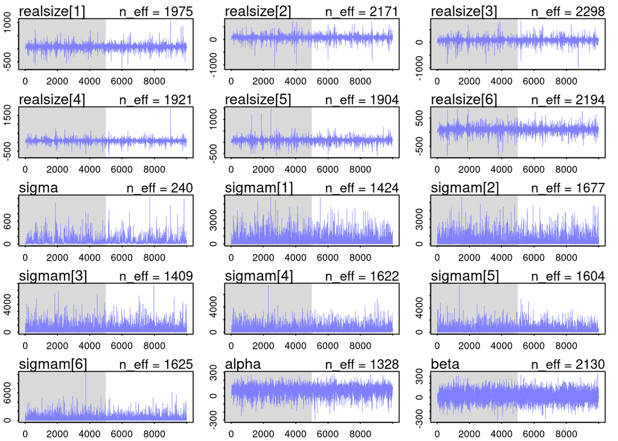

```r
traceplot(sc1posterior)
```

The parameter imprecision is clearly visible on the predictions of expected real tree height values.

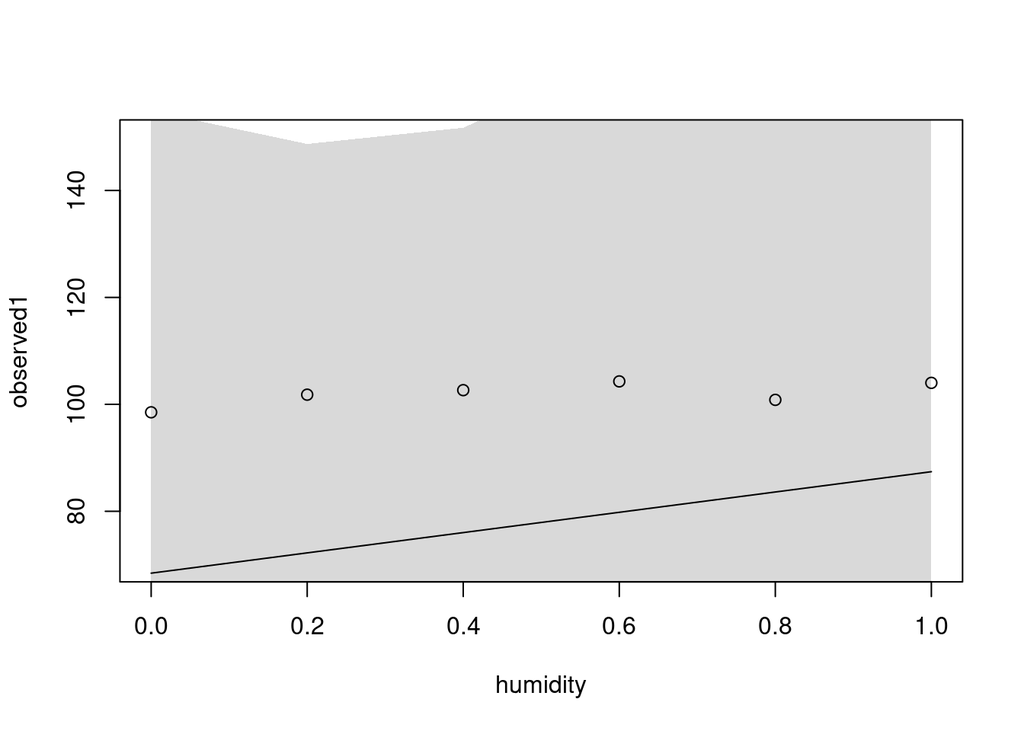

```r
yexpsc1=link(sc1posterior)

yexpmeansc1=apply(yexpsc1,2, mean)
yexpPIsc1=apply(yexpsc1,2, PI)

plot(observed1~humidity, data=sc1data, ylim=c(70,150))
lines(sc1data$humidity , yexpmeansc1)
shade(yexpPIsc1 , sc1data$humidity)
```

The prediction lines are completely out of the data.

# Solution and example 2

OK, so we don’t have enough data to estimate all sigmam values. Perhaps we can help ourselves by assuming that all the sigmam values are the same.

```r
sc1ssmodel=alist(
  observed1 ~ dnorm(realsize[id], sigmam),
  realsize[id] ~ dnorm(mu, sigma),
  mu <- alpha + beta*humidity,

  sigma ~ dexp(0.001),
  sigmam ~ dexp(0.001),
  alpha ~ dnorm(0, 100),
  beta ~ dnorm(0,100)

)
```

And fit it.

```r
sc1ssposterior=ulam(sc1ssmodel,
                    data=sc1data,iter = 10000)
```

[output not shown]

[output cut: 50 more lines]

[output not shown]

We see that the precision of estimates improved dramatically.

```r
precis(sc1ssposterior) # single sigmam
```

```
## 6 vector or matrix parameters hidden. Use depth=2 to show them.
```

```
##             mean       sd       5.5%      94.5%     rhat    ess_bulk
## sigma   2.688887 5.426517  0.3603020   7.855926 1.217381    3.544566
## sigmam  3.326717 6.203124  0.3689525   7.141397 1.094519   12.058434
## alpha  99.539460 5.719347 94.9829365 104.324330 1.190939 1064.815455
## beta    4.093334 9.337010 -3.2167749  12.652744 1.141789  751.204515
```

```r
precis(sc1posterior) # multiple sigmam
```

```
## 12 vector or matrix parameters hidden. Use depth=2 to show them.
```

```
##           mean       sd        5.5%    94.5%     rhat  ess_bulk
## sigma 77.75988 93.09379    7.072785 235.0613 1.000136  240.3762
## alpha 68.42961 62.55504  -42.062694 154.8749 1.000064 1327.8599
## beta  18.97682 78.49360 -106.806435 144.1500 1.000391 2129.9541
```

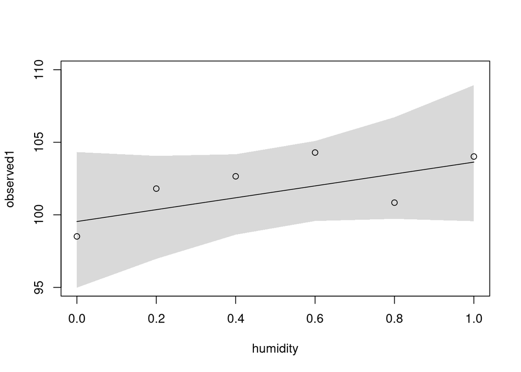

```r
yexpsc1ss=link(sc1ssposterior)

yexpmeansc1ss=apply(yexpsc1ss,2, mean)
yexpPIsc1ss=apply(yexpsc1ss,2, PI)

plot(observed1~humidity, data=sc1data, ylim=c(95,110))
lines(sc1data$humidity , yexpmeansc1ss)
shade(yexpPIsc1ss , sc1data$humidity)
```

# Solution and example 3

Alternatively, we can also directly advise the model on our prior expectation what sigmam is. For instance we know based on previous experience that it is between 1 and 3.

```r
sc1rpmodel=alist(
  observed1 ~ dnorm(realsize[id], sigmam[id]),
  realsize[id] ~ dnorm(mu, sigma),
  mu <- alpha + beta*humidity,

  sigma ~ dexp(0.01),
  sigmam[id] ~ dexp(1),
  alpha ~ dnorm(0, 100),
  beta ~ dnorm(0,100)

)
```

And fit it.

```r
sc1rpposterior=ulam(sc1rpmodel,
                 data=sc1data,iter = 10000)
```

[output not shown]

[output cut: 50 more lines]

[output not shown]

We see that the precision of estimates improved even more.

```r
precis(sc1rpposterior) # restrictive prior
```

```
## 12 vector or matrix parameters hidden. Use depth=2 to show them.
```

```
##            mean       sd      5.5%      94.5%     rhat  ess_bulk
## sigma  2.533842 2.736270  0.387696   5.963271 1.020878  88.33669
## alpha 99.995722 3.273615 96.034492 103.338220 1.016947 181.25667
## beta   4.190893 5.174829 -1.315053  10.518715 1.006031 492.72058
```

```r
precis(sc1ssposterior) # single sigmam
```

```
## 6 vector or matrix parameters hidden. Use depth=2 to show them.
```

```
##             mean       sd       5.5%      94.5%     rhat    ess_bulk
## sigma   2.688887 5.426517  0.3603020   7.855926 1.217381    3.544566
## sigmam  3.326717 6.203124  0.3689525   7.141397 1.094519   12.058434
## alpha  99.539460 5.719347 94.9829365 104.324330 1.190939 1064.815455
## beta    4.093334 9.337010 -3.2167749  12.652744 1.141789  751.204515
```

```r
precis(sc1posterior) # multiple sigmam
```

```
## 12 vector or matrix parameters hidden. Use depth=2 to show them.
```

```
##           mean       sd        5.5%    94.5%     rhat  ess_bulk
## sigma 77.75988 93.09379    7.072785 235.0613 1.000136  240.3762
## alpha 68.42961 62.55504  -42.062694 154.8749 1.000064 1327.8599
## beta  18.97682 78.49360 -106.806435 144.1500 1.000391 2129.9541
```

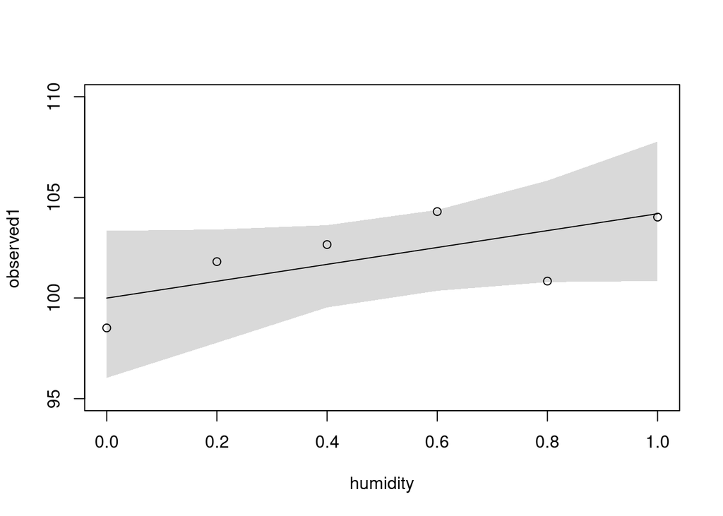

```r
yexpsc1rp=link(sc1rpposterior)

yexpmeansc1rp=apply(yexpsc1rp,2, mean)
yexpPIsc1rp=apply(yexpsc1rp,2, PI)

plot(observed1~humidity, data=sc1data,ylim=c(95,110))
lines(sc1data$humidity , yexpmeansc1rp)
shade(yexpPIsc1rp , sc1data$humidity)
```

# Trick question

What if we wanted to hardwire sigmam to 2?

# No replacement for displacement amount of data

[figure not shown]

The less sophisticated model with a lot of data may simply perform better. But not much better in fact.

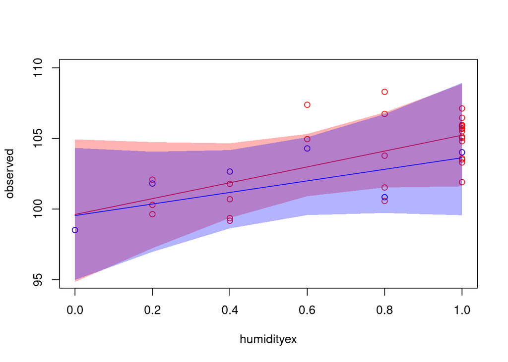

```r
plot(observed~humidityex, data=scdata, col="red", ylim=c(95,110))
points(observed1~humidity, data=sc1data, col="blue")

lines(scdata$humidity , yexpmeansc, col="red")
shade(yexpPIsc , scdata$humidity, col=alpha("red", alpha=0.3))

lines(sc1data$humidity , yexpmeansc1ss, col="blue")
shade(yexpPIsc1ss , sc1data$humidity, col=alpha("blue", alpha=0.3))
```